# SRNM_Modeling-Course

Ernest Fotsing, PhD University of Fribourg

2025-11-03

# **Introduction**

## The goal of this exercice is to :

1. dowload covariate file from website in R: in this case it will digital elevation mode, then,import shp and overlay it in dem with other shp and make a grid of 2*2km size and extract centroide
2. plot that covariates just for exploration and export your research site covariate and plot it to see how it look like
3. Crop your research site from this raster filed
4. Add a grid and extract centroid that fall inside your research site
5. import your centroid in excel or CSV or text file
6. map your research site_cov
7. import you map in pdf, png and jpeg
8. Perform Model selection on data obtained from the exercice

## **1. Getting Started**

### **1.1 Installing Packages**

```r
install_and_load_packages <- function() {
  # List of required packages
  packages <- c(
    "openxlsx", "WriteXLS", "writexl", "raster", "sp", "sf",
    "parallel", "readr", "sfheaders", "stars", "terra", "Matrix",
    "lattice", "abind", "xlsx", "usdm", "AICcmodavg", "corrplot",
    "tidyverse", "coefplot", "GGally", "pgirmess", "influence.ME",
    "MuMIn", "DHARMa", "dplyr", "MASS", "ncf", "visreg"
  )

  # Install any packages that are missing
  new_packages <- packages[!(packages %in% installed.packages()[,"Package"])]
  if(length(new_packages)) {
    message("Installing missing packages: ", paste(new_packages, collapse = ", "))
    install.packages(new_packages, dependencies = TRUE)
  }

  # Load all packages
  invisible(lapply(packages, function(pkg) {
    suppressPackageStartupMessages(library(pkg, character.only = TRUE))
  }))

  # Set ggplot theme
  if ("ggplot2" %in% loadedNamespaces()) {
    ggplot2::theme_set(ggplot2::theme_bw(base_size = 12))
  }

  message("all packages installed and loaded successfully!")
}
```

### **1.2 Introduction to Linear Modelling with R**

```r
rm(list= ls()) #To remove all objects, issue the command
```

### **Description**

The course will cover ANOVA, linear regression and some extensions. It will be a mixture of lectures and hands-on time using RStudio to analyse data.

### **Aims: During this course you will learn about**:

### **Simple and multiple regression: Generalised Linear Models**

Introduction to more advanced topics, like non-linear models and time series. Objectives: After this course you should be able to - Realise the connection between t-tests, ANOVA and linear regression - Fit a linear regression - Check if the assumptions of linear regression are met by the data and what to do if they are not - Know when linear regression is not appropriate and have an idea of which alternative method might be appropriate - Know when you need to seek help with analysis as the data structure is too complex for the methods taught

###**Course Data** [Please Download this zip file to have all the datasets and R files used in this course](https://bioinformatics-core-shared-training.github.io/linear-models-r/Course_Data.zip)

#### **The purpose of this section is to review some of the key concepts in basic R usage, and statistical testing**

-Reading data into R

-The data-frame representation of data in R

-Selecting rows and columns from a data frame

-Computing numerical summaries

-Basic plotting

-Getting help on functions in RStudio

## Reading and inspecting the data

Like other software (Word, Excel, Photoshop….), R has a default location where it will save files to and import data from. This is known as the working directory in R. You can query what R currently considers its working directory by executing the following R command:-

```r
getwd()
```

```
## [1] "C:/Users/lenovo/OneDrive/Bureau/SNRM_Training/R_Precourse_ErnestFotsing/LM"
```

*N.B.*Here, a set of open and closed brackets () is used to run the `getwd` function with no arguments.  
*Note if you are following this material on a Windows machine as opposed to a Linux or MacOS machine you will get a path like C:. If you want to use the complementing R command ‘setwd()’ to set the working directory you MUST escape the i.e. setwd(“C:\Users\Fred”).  
We can also list the files in a specific directory with:-

```r
list.files("./CourseData/")
```

```
##  [1] "02_water_cons.txt"          "amess.csv"
##  [3] "Assay.txt"                  "Bronchitis.csv"
##  [5] "clinicalTrials.txt"         "crab.csv"
##  [7] "diet.csv"                   "genotypes.txt"
##  [9] "globalBreastCancerRisk.csv" "lactoferrin.csv"
## [11] "myCleanTreeData.RDS"        "myocardialinfarction.csv"
## [13] "OscillationIndex.txt"       "pollution.csv"
## [15] "protein-expression.csv"     "students.csv"
## [17] "temperature.csv"            "treatments.txt"
```

A useful sanity check is the file.exists function which will print TRUE is the file can be found in the working directory.

```r
file.exists("./CourseData/diet.csv")
```

```
## [1] TRUE
```

- Assuming the file can be found, we can use the `read.csv` function to import the data. Other functions can be used to read tab-delimited files (read.delim) or a generic read.table function. A data frame object is created.
- The file name `diet.csv` is the only *argument* to the function `read.csv`
  - arguments are listed inside the brackets
  - for functions requiring more than one argument (input), arguments are separated by commas
  - a function may have default values for some arguments; meaning they do not need to be specified
- The characters `<-` are used to tell R to create a variable
  - without this, the data are not loaded into memory and you won’t be able to work with them
- If you get an error saying `Error in file(file, “rt”) : cannot open the connection...`, you might need to change your working directory or make sure the file name is typed correctly (R is case-sensitive)
- Typing the name of an object will cause R to print the contents to the screen

```r
diet <- read.csv("./CourseData/diet.csv")
head(diet)
```

```
##   id gender age height diet.type initial.weight final.weight
## 1  1 Female  22    159         A             58         54.2
## 2  2 Female  46    192         A             60         54.0
## 3  3 Female  55    170         A             64         63.3
## 4  4 Female  33    171         A             64         61.1
## 5  5 Female  50    170         A             65         62.2
## 6  6 Female  50    201         A             66         64.0
```

### **A note on importing your own data**

If you are trying to read your own data, and encounter an error at this stage, you may need to consider if your data are in the correct form for analysis. Like most programming languages, R will struggle if your spreadsheet has been heavily formatted to include colours, formulas and special formatting.

These references will guide you through some of the pitfalls and common mistakes to avoid when formatting data

- [Formatting data tables in Spreadsheets](http://www.datacarpentry.org/spreadsheet-ecology-lesson/01-format-data.html)
- [Data Organisation tutorial by Karl Broman](http://kbroman.org/dataorg/)
- [The Quartz guide to bad data](https://github.com/Quartz/bad-data-guide/blob/master/README.md)

`diet` is an example of a data frame. The data frame object in R allows us to work with “tabular” data, like we might be used to dealing with in Excel, where our data can be thought of having rows and columns. The values in each column have to all be of the same type (i.e. all numbers or all text).

- the `summary` function will provide a overview of the contents of each column in the table
  - the type of summary provided depends on the data type in each column

```r
summary(diet)
```

```
##        id           gender               age            height
##  Min.   : 1.00   Length:76          Min.   :16.00   Min.   :141.0
##  1st Qu.:19.75   Class :character   1st Qu.:32.50   1st Qu.:163.8
##  Median :40.50   Mode  :character   Median :39.00   Median :169.0
##  Mean   :39.87                      Mean   :39.22   Mean   :170.8
##  3rd Qu.:59.25                      3rd Qu.:47.25   3rd Qu.:175.2
##  Max.   :78.00                      Max.   :60.00   Max.   :201.0
##   diet.type         initial.weight   final.weight
##  Length:76          Min.   :58.00   Min.   :53.00
##  Class :character   1st Qu.:66.00   1st Qu.:61.95
##  Mode  :character   Median :72.00   Median :68.95
##                     Mean   :72.29   Mean   :68.34
##                     3rd Qu.:78.00   3rd Qu.:73.67
##                     Max.   :88.00   Max.   :84.50
```

- particular columns can be accessed using the `$` operator
  - *TIP* RStudio will allow auto-complete using the *Tab* key

```r
diet$gender
```

```
##  [1] "Female" "Female" "Female" "Female" "Female" "Female" "Female" "Female"
##  [9] "Female" "Female" "Female" "Female" "Female" "Female" "Female" "Female"
## [17] "Female" "Female" "Female" "Female" "Female" "Female" "Female" "Female"
## [25] "Female" "Female" "Female" "Female" "Female" "Female" "Female" "Female"
## [33] "Female" "Female" "Female" "Female" "Female" "Female" "Female" "Female"
## [41] "Female" "Female" "Female" "Male"   "Male"   "Male"   "Male"   "Male"
## [49] "Male"   "Male"   "Male"   "Male"   "Male"   "Male"   "Male"   "Male"
## [57] "Male"   "Male"   "Male"   "Male"   "Male"   "Male"   "Male"   "Male"
## [65] "Male"   "Male"   "Male"   "Male"   "Male"   "Male"   "Male"   "Male"
## [73] "Male"   "Male"   "Male"   "Male"
```

```r
diet$age
```

```
##  [1] 22 46 55 33 50 50 37 28 28 45 60 48 41 37 44 37 41 43 20 51 31 54 50 48 16
## [26] 37 30 29 51 35 21 22 36 20 35 45 58 37 31 35 56 48 41 39 31 40 50 43 25 52
## [51] 42 39 40 51 38 54 33 45 37 44 40 37 39 31 36 47 29 37 31 26 40 35 49 28 40
## [76] 51
```

We can create new columns based on existing ones

```r
diet$weight.loss <- diet$final.weight - diet$initial.weight
```

Subsetting rows and columns is done using the `[rows, columns]` syntax; where `rows` and `columns` are *vectors* containing the rows and columns you want

- you can choose to omit either vector to show all rows and columns. *However, you still need to remember the `,`

```r
diet[1:5,]
```

```
##   id gender age height diet.type initial.weight final.weight weight.loss
## 1  1 Female  22    159         A             58         54.2        -3.8
## 2  2 Female  46    192         A             60         54.0        -6.0
## 3  3 Female  55    170         A             64         63.3        -0.7
## 4  4 Female  33    171         A             64         61.1        -2.9
## 5  5 Female  50    170         A             65         62.2        -2.8
```

```r
#diet[,2:3]
```

Logical tests can be used to select rows. e.g. using `==`, `<`, `>`

```r
diet$diet.type == "A"
```

```
##  [1]  TRUE  TRUE  TRUE  TRUE  TRUE  TRUE  TRUE  TRUE  TRUE  TRUE  TRUE  TRUE
## [13]  TRUE  TRUE FALSE FALSE FALSE FALSE FALSE FALSE FALSE FALSE FALSE FALSE
## [25] FALSE FALSE FALSE FALSE FALSE FALSE FALSE FALSE FALSE FALSE FALSE FALSE
## [37] FALSE FALSE FALSE FALSE FALSE FALSE FALSE  TRUE  TRUE  TRUE  TRUE  TRUE
## [49]  TRUE  TRUE  TRUE  TRUE  TRUE FALSE FALSE FALSE FALSE FALSE FALSE FALSE
## [61] FALSE FALSE FALSE FALSE FALSE FALSE FALSE FALSE FALSE FALSE FALSE FALSE
## [73] FALSE FALSE FALSE FALSE
```

```r
dietA <- diet[diet$diet.type == "A",]
head(dietA)
```

```
##   id gender age height diet.type initial.weight final.weight weight.loss
## 1  1 Female  22    159         A             58         54.2        -3.8
## 2  2 Female  46    192         A             60         54.0        -6.0
## 3  3 Female  55    170         A             64         63.3        -0.7
## 4  4 Female  33    171         A             64         61.1        -2.9
## 5  5 Female  50    170         A             65         62.2        -2.8
## 6  6 Female  50    201         A             66         64.0        -2.0
```

## **Visualisation**

All your favourite types of plot can be created in R

- Simple plots are supported in the *base* distribution of R (what you get automatically when you download R).
  - `boxplot`, `hist`, `barplot`,… all of which are extensions of the basic `plot` function
- Many different customisations are possible
  - colour, overlay points / text, legends, multi-panel figures
- *You need to think about how best to visualise your data*
  - http://www.bioinformatics.babraham.ac.uk/training.html#figuredesign
- R cannot prevent you from creating a plotting disaster:
  - http://www.businessinsider.com/the-27-worst-charts-of-all-time-2013-6?op=1&IR=T

Plots can be constructed from vectors of numeric data, such as the data we get from a particular column in a data frame.

- a histogram is commonly-used to examine the distribution of a particular variable

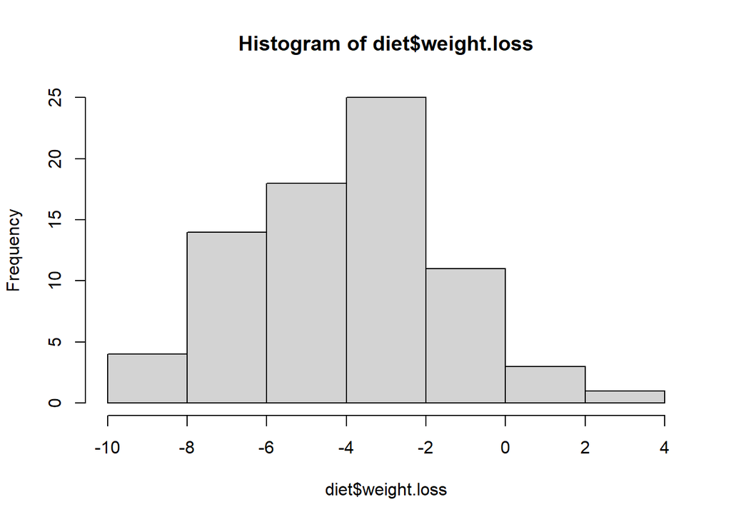

```r
hist(diet$weight.loss)
```

- a boxplot is often used to compare distributions visually
  - if given a data-frame, each column will be shown as a separate box
  - otherwise the formula syntax `~` is used to define x and y variables

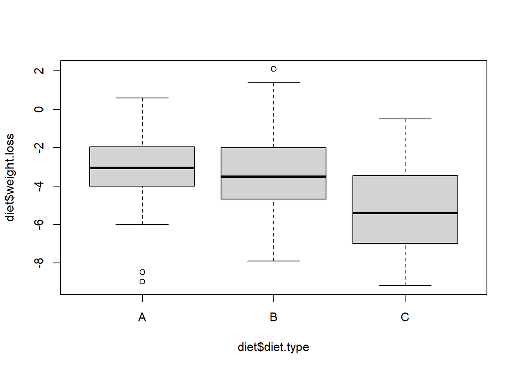

```r
boxplot(diet$weight.loss~diet$diet.type)
```

- scatter plots can be constructed by given two vectors as arguments to `plot`

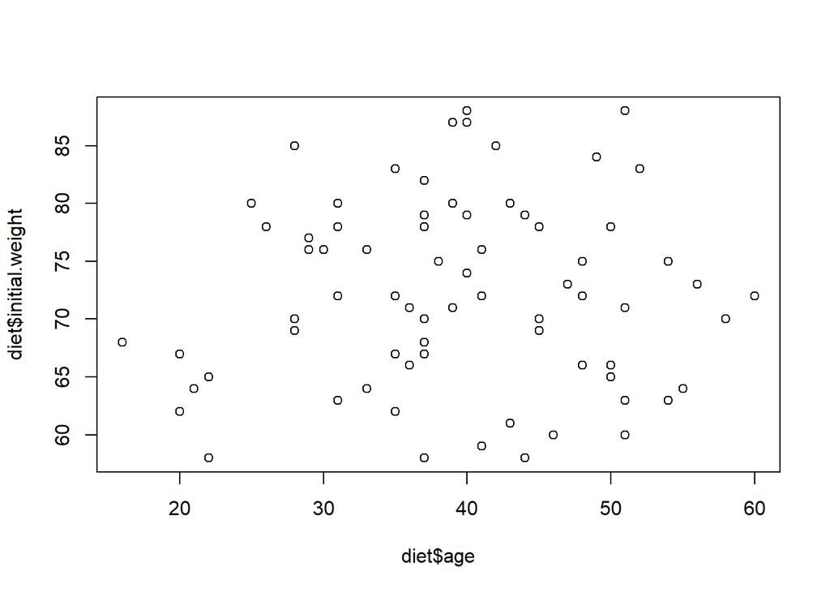

```r
plot(diet$age,diet$initial.weight)
```

*Lots* of customisations are possible to enhance the appaerance of our plots. Not for the faint-hearted, the help pages `?plot` and `?par` give the full details. In short,

- Axis labels, and titles can be specified as character strings.
- R recognises many preset names as colours. To get a full list use `colours()`, or check this [online reference](http://www.stat.columbia.edu/~tzheng/files/Rcolor.pdf).
  - can also use `*R*ed, *G*reen, *B*lue values; which you might get from a paint program
- Plotting characters can be specified using a pre-defined number

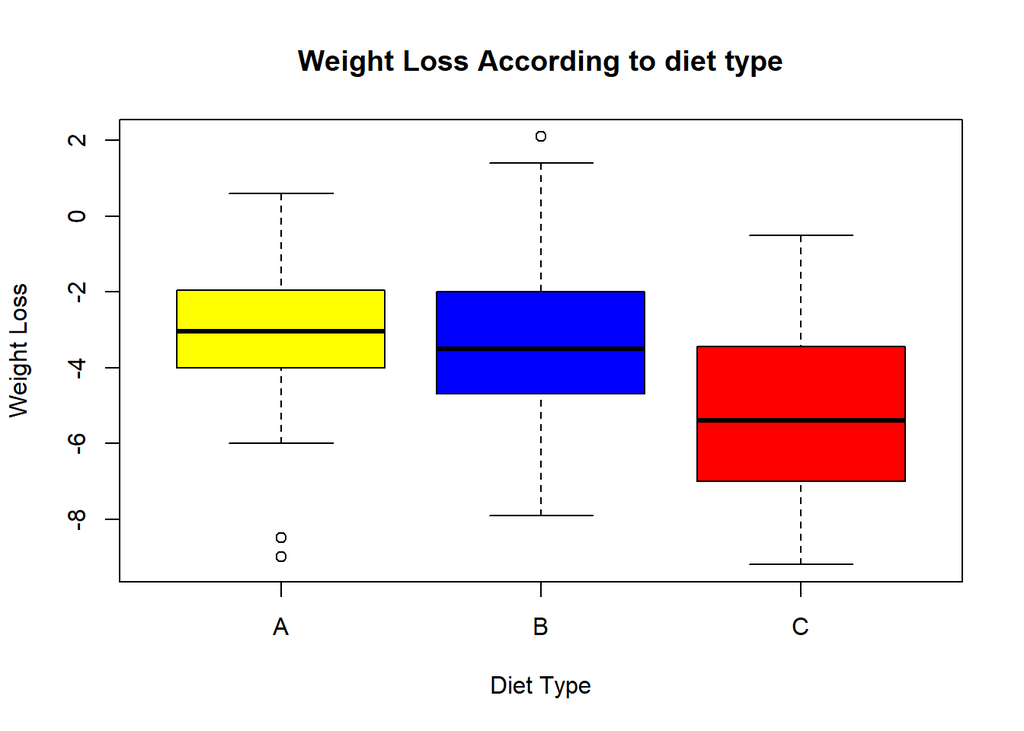

```r
boxplot(diet$weight.loss~diet$diet.type,
        ylab="Weight Loss",
        xlab="Diet Type",
        col=c("yellow","blue","red"),
        main="Weight Loss According to diet type")
```

You can get help on any of the functions that we will be using in this course by using the ‘?’ or ‘help()’ commands. The help will appear in the help pane (usually bottom RH corner) .

```r
?lm
```

```
## démarrage du serveur d'aide httpd ... fini
```

```r
help(lm)
```

# **Section 1: Descriptive analysis**

Lets starts by

- importing again the data set (such that we overwrite the previous one) *diet* with the function `read.csv()`
- defining a new column *weight.loss*, corresponding to the difference between the initial and final weights (respectively the corresponding to the columns `initial.weight` and `final.weight` of the dataset)
- displaying *weight loss* per *diet type* (column `diet.type`) by means of a boxplot.

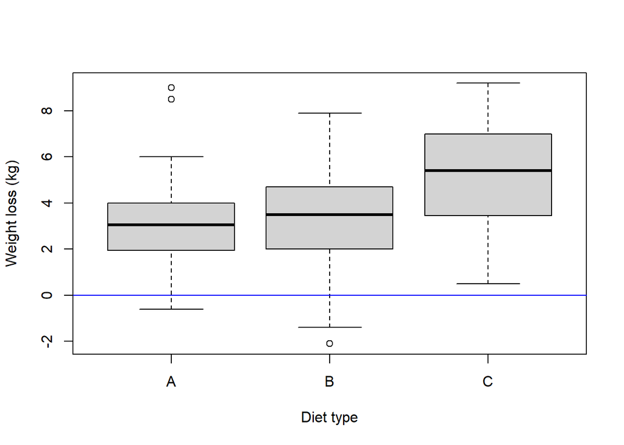

```r
diet = read.csv("./CourseData/diet.csv",row.names=1)
diet$weight.loss = diet$initial.weight - diet$final.weight
diet$diet.type   = factor(diet$diet.type,levels=c("A","B","C"))
diet$gender      = factor(diet$gender,levels=c("Female","Male"))
boxplot(weight.loss~diet.type,data=diet,col="light gray",
        ylab = "Weight loss (kg)", xlab = "Diet type")
abline(h=0,col="blue")
```

# Section 2: **ANOVA**

Lets

- perform a Fisher’s, Welch’s and Kruskal-Wallis one-way ANOVA, respectively by means of the functions `aov()`, `oneway.test()` and `kruskal.test`,
- display and analyse the results: Use the function `summary()` to display the results of an R object of class `aov` and the function `print()` otherwise.

## Differences between Fisher’s, Welch’s, and Kruskal–Wallis One-Way ANOVA

- **Type:** Parametric test (robust version of ANOVA)
- **Purpose:** Tests whether group *means* differ when variances are **unequal**
- **Assumptions:**
  - Data in each group are **normally distributed**
  - **Variances can differ** between groups
  - Observations are **independent**
- **When to use:** When data are **normal** but **variances are unequal**

### 3. Kruskal–Wallis One-Way ANOVA

- **Type:** Non-parametric test
- **Purpose:** Tests whether group *medians* differ (uses ranks instead of raw data)
- **Assumptions:**
  - No **normality** assumption required
  - Distributions should have **similar shapes**
  - Observations are **independent**
- **When to use:** When data are **not normally distributed** or are **ordinal**  
  ### Summary Table

| Test | Parametric | Equal Variances Required | Tests Means or Medians | Suitable for Non-Normal Data |
| --- | --- | --- | --- | --- |
| **Fisher’s ANOVA** | Yes | Yes | Means | No |
| **Welch’s ANOVA** | Yes | No | Means | No |
| **Kruskal–Wallis** | No | No (but similar shapes) | Medians | Yes |

```r
diet.fisher  = aov(weight.loss~diet.type,data=diet)
diet.welch   = oneway.test(weight.loss~diet.type,data=diet)
diet.kruskal = kruskal.test(weight.loss~diet.type,data=diet)

summary(diet.fisher)
```

```
##             Df Sum Sq Mean Sq F value Pr(>F)
## diet.type    2   60.5  30.264   5.383 0.0066 **
## Residuals   73  410.4   5.622
## ---
## Signif. codes:  0 '***' 0.001 '**' 0.01 '*' 0.05 '.' 0.1 ' ' 1
```

```r
print(diet.welch)
```

```
##
##  One-way analysis of means (not assuming equal variances)
##
## data:  weight.loss and diet.type
## F = 5.2693, num df = 2.00, denom df = 48.48, p-value = 0.008497
```

```r
print(diet.kruskal)
```

```
##
##  Kruskal-Wallis rank sum test
##
## data:  weight.loss by diet.type
## Kruskal-Wallis chi-squared = 9.4159, df = 2, p-value = 0.009023
```

Note that, when the interest lies in the difference between two means, the Fisher’s ANOVA (fonction `aov()`) and the Student’s t-test (function `t.test()` with argument `var.equal` set to `TRUE`) leads to the same results. Let check this by comparing the mean weight losses of *Diet A* and *Diet C*.

```r
summary(aov(weight.loss~diet.type,data=diet[diet$diet.type!="B",]))
```

```
##             Df Sum Sq Mean Sq F value  Pr(>F)
## diet.type    1   43.4    43.4   8.036 0.00664 **
## Residuals   49  264.6     5.4
## ---
## Signif. codes:  0 '***' 0.001 '**' 0.01 '*' 0.05 '.' 0.1 ' ' 1
```

```r
t.test(weight.loss~diet.type,data=diet[diet$diet.type!="B",],var.equal = TRUE)
```

```
##
##  Two Sample t-test
##
## data:  weight.loss by diet.type
## t = -2.8348, df = 49, p-value = 0.006644
## alternative hypothesis: true difference in means between group A and group C is not equal to 0
## 95 percent confidence interval:
##  -3.1582988 -0.5379975
## sample estimates:
## mean in group A mean in group C
##        3.300000        5.148148
```

# **Model check**

Lets first

- define the Fisher’s and Welch’s residuals by subtracting the mean of each group to the weight loss of the corresponding participants
- define the Kruskal’s residual’s by subtraction the median of each group to the weight loss of the corresponding participants

The mean or median of each group may be obtained by means of the function `tapply()` which allows a apply a function (like `mean` or `median`) to and by

```r
# mean and median weight loss per group:
mean_group   = tapply(diet$weight.loss,diet$diet.type,mean)
median_group = tapply(diet$weight.loss,diet$diet.type,median)
mean_group
```

```
##        A        B        C
## 3.300000 3.268000 5.148148
```

```r
median_group
```

```
##    A    B    C
## 3.05 3.50 5.40
```

```r
# residuals:
diet$resid.mean   = (diet$weight.loss - mean_group[as.numeric(diet$diet.type)])
diet$resid.median = (diet$weight.loss - median_group[as.numeric(diet$diet.type)])
diet[1:5,]
```

```
##   gender age height diet.type initial.weight final.weight weight.loss
## 1 Female  22    159         A             58         54.2         3.8
## 2 Female  46    192         A             60         54.0         6.0
## 3 Female  55    170         A             64         63.3         0.7
## 4 Female  33    171         A             64         61.1         2.9
## 5 Female  50    170         A             65         62.2         2.8
##   resid.mean resid.median
## 1        0.5         0.75
## 2        2.7         2.95
## 3       -2.6        -2.35
## 4       -0.4        -0.15
## 5       -0.5        -0.25
```

Then, lets

- display a boxplot of the residuals per group to assess if (i) the variance per groups are similar (ii) normality of the residuals per group seems credible
- display a QQ-plot of the residuals of the mean model to assess if normality of the residuals seems credible

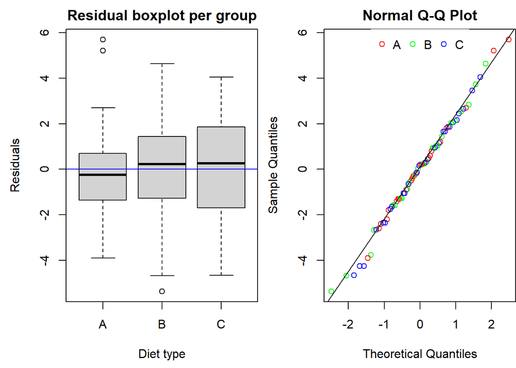

```r
par(mfrow=c(1,2),mar=c(4.5,4.5,2,0))
#
boxplot(resid.mean~diet.type,data=diet,main="Residual boxplot per group",col="light gray",xlab="Diet type",ylab="Residuals")
abline(h=0,col="blue")
#
col_group = rainbow(nlevels(diet$diet.type))
qqnorm(diet$resid.mean,col=col_group[as.numeric(diet$diet.type)])
qqline(diet$resid.mean)
legend("top",legend=levels(diet$diet.type),col=col_group,pch=21,ncol=3,box.lwd=NA)
```

Finally, lets

- perform a Shapiro’s test to assess is there is enough evidence that the residuals are not normally distributed (by means of the function `shapiro.test()`)
- perform a Bartlett’s test to assess is there is enough evidence that the residuals per group do not have different variance (by means of the function `bartlett.test()`. )

```r
shapiro.test(diet$resid.mean)
```

```
##
##  Shapiro-Wilk normality test
##
## data:  diet$resid.mean
## W = 0.99175, p-value = 0.9088
```

```r
bartlett.test(diet$resid.mean~as.numeric(diet$diet.type))
```

```
##
##  Bartlett test of homogeneity of variances
##
## data:  diet$resid.mean by as.numeric(diet$diet.type)
## Bartlett's K-squared = 0.21811, df = 2, p-value = 0.8967
```

#### **Mutiple comparisons**

Lets

- perform a Tukey HSD test to define which group pair(s) have different means (by means of the function `TukeyHSD()`)
- compare the Tukey HSD confidence interval size for the difference of means between the weight losses of *Diet A* and *Diet B* with the one obtained by means of a Student’s t-test (function `t.test()` with argument `var.equal` set to `TRUE`)

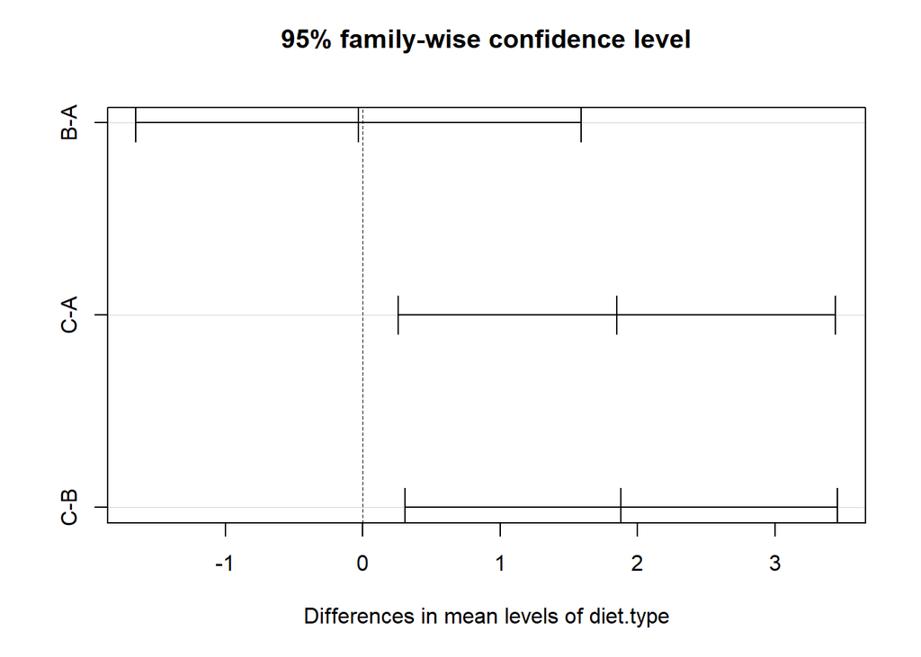

```r
plot(TukeyHSD(diet.fisher))
```

```r
t.test(weight.loss~diet.type,data=diet[diet$diet.type!="C",],var.equal = TRUE)
```

```
##
##  Two Sample t-test
##
## data:  weight.loss by diet.type
## t = 0.0475, df = 47, p-value = 0.9623
## alternative hypothesis: true difference in means between group A and group B is not equal to 0
## 95 percent confidence interval:
##  -1.323275  1.387275
## sample estimates:
## mean in group A mean in group B
##           3.300           3.268
```

# Section 5: **Two-way ANOVA**

Lets

```r
diet.fisher = aov(weight.loss~diet.type*gender,data=diet)
summary(diet.fisher)
```

```
##                  Df Sum Sq Mean Sq F value  Pr(>F)
## diet.type         2   60.5  30.264   5.629 0.00541 **
## gender            1    0.2   0.169   0.031 0.85991
## diet.type:gender  2   33.9  16.952   3.153 0.04884 *
## Residuals        70  376.3   5.376
## ---
## Signif. codes:  0 '***' 0.001 '**' 0.01 '*' 0.05 '.' 0.1 ' ' 1
```

```r
anova(lm(weight.loss~diet.type*gender,data=diet))
```

```
## Analysis of Variance Table
##
## Response: weight.loss
##                  Df Sum Sq Mean Sq F value   Pr(>F)
## diet.type         2  60.53 30.2635  5.6292 0.005408 **
## gender            1   0.17  0.1687  0.0314 0.859910
## diet.type:gender  2  33.90 16.9520  3.1532 0.048842 *
## Residuals        70 376.33  5.3761
## ---
## Signif. codes:  0 '***' 0.001 '**' 0.01 '*' 0.05 '.' 0.1 ' ' 1
```

# **Practicals Exercice**

Analyse the two following datasets with the suitable analysis:

## (i) *amess.csv*

The data for this exercise are to be found in *amess.csv*. The data are the red cell folate levels in three groups of cardiac bypass patients given different levels of nitrous oxide (N2O) and oxygen (O2) ventilation. (There is a reference to the source of this data in Altman, Practical Statistics for Medical Research, p. 208.) The treatments are

- 50% N2O and 50% O2 continuously for 24 hours
- 50% N2O and 50% O2 during the operation
- No N2O but 35-50% O2 continuously for 24 hours

## (ii) *globalBreastCancerRisk.csv*

The file *globalBreastCancerRisk.csv* gives the number of new cases of Breast Cancer (per population of 10,000) in various countries around the world, along with various health and lifestyle risk factors.

Let’s suppose we are initially interested in whether the number of breast cancer cases is significantly different in different regions of the world.

Visualise the distribution of breast cancer incidence in each continent. Check how many observations belong to each group (continent). Are there any groups that you would consider removing/grouping before performing the analysis ?

# **Simple Regression with R**

#### Correlation Coefficients

We’ll start by generating some synthetic data to investigate correlation coefficients.

Generate 50 random numbers in the range [0,50]:

```r
x = runif(50,0,50)
```

Now let’s generate some y-values that are linearly correlated with the x-values with gradient=1, applying a random Normal offset (with sd=5):

```r
y = x + rnorm(50,0,5)
```

Plotting y against x, you’ll observe a positive linear relationship:

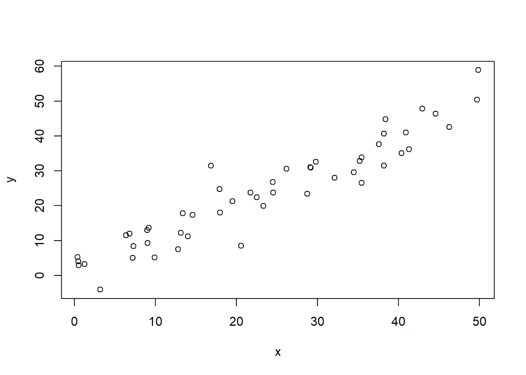

```r
plot(y~x)
```

This strong linear relationship is reflected in the correlation coefficient and in the coefficient of determination (R^2):

```r
pearson_cor_coef = cor(x,y)
list("cor"=pearson_cor_coef,"R^2"=pearson_cor_coef^2)
```

```
## $cor
## [1] 0.9436747
##
## $`R^2`
## [1] 0.890522
```

If the data exhibit a negative linear correlation then the correlation coefficient will become strong and negative, whilst the R^2 value will remain strong and positive:

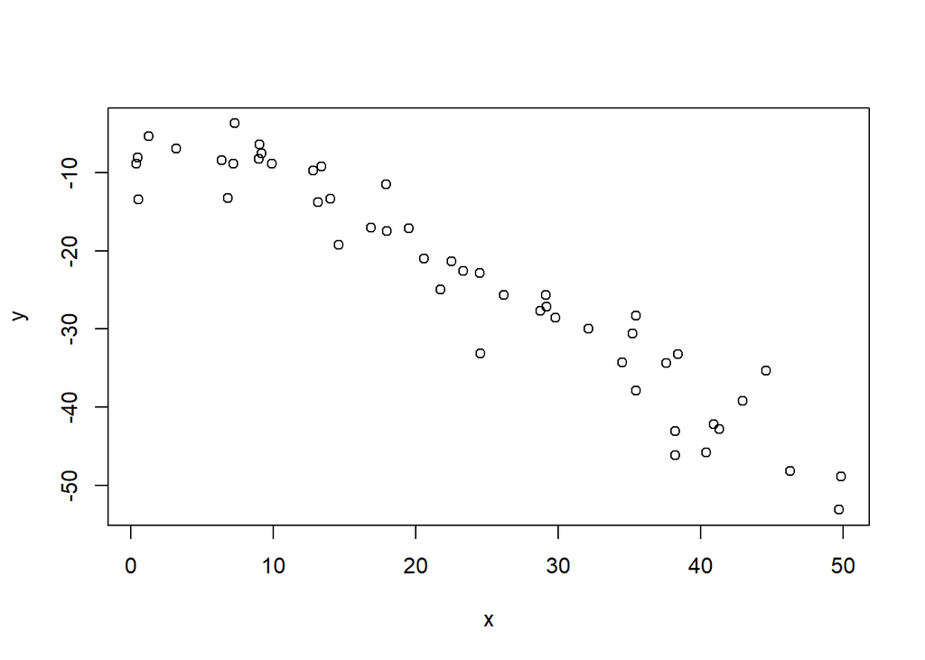

```r
y = -x + rnorm(50,0,5)
plot(y~x)
```

```r
pearson_cor_coef = cor(x,y)
list("cor"=pearson_cor_coef,"R^2"=pearson_cor_coef^2)
```

```
## $cor
## [1] -0.9525653
##
## $`R^2`
## [1] 0.9073806
```

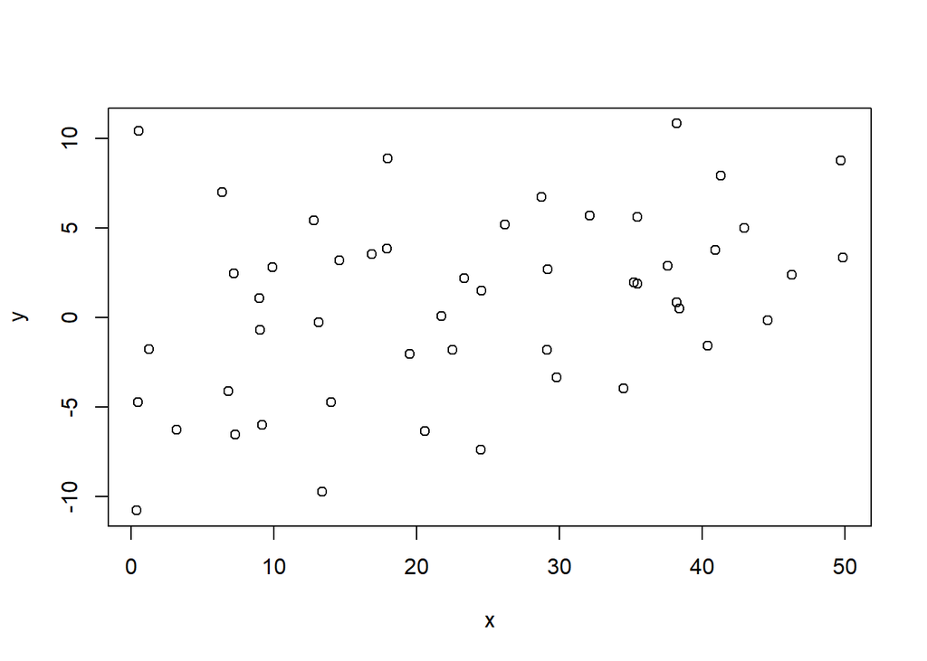

```r
y = rnorm(50,0,5)
plot(y~x)
```

```r
pearson_cor_coef = cor(x,y)
list("cor"=pearson_cor_coef,"R^2"=pearson_cor_coef^2)
```

```
## $cor
## [1] 0.3708177
##
## $`R^2`
## [1] 0.1375058
```

The significance of a correlation can be tested using `cor.test()`, which also provides a 95% confidence interval on the correlation:

```r
cor.test(x,y)
```

```
##
##  Pearson's product-moment correlation
##
## data:  x and y
## t = 2.7663, df = 48, p-value = 0.008025
## alternative hypothesis: true correlation is not equal to 0
## 95 percent confidence interval:
##  0.1031129 0.5884299
## sample estimates:
##       cor
## 0.3708177
```

# Application of lm with real data

Now let’s look at some real data.

The in-built dataset `trees` contains data pertaining to the `Volume`, `Girth` and `Height` of 31 felled black cherry trees.

We will now attempt to construct a simple linear model that uses `Girth` to predict `Volume`.

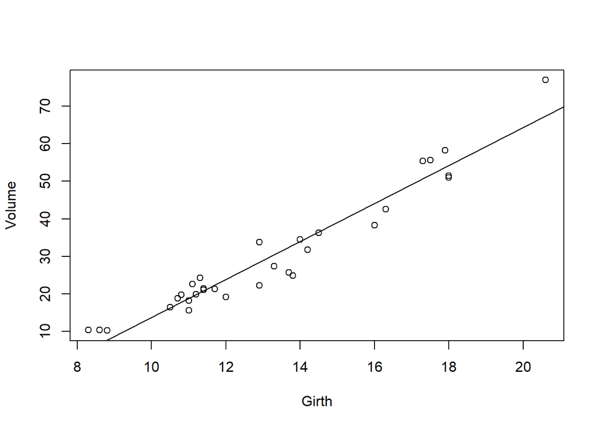

```r
plot(Volume~Girth,data=trees)
m1 = lm(Volume~Girth,data=trees)
abline(m1)
```

```r
cor.test(trees$Volume,trees$Girth)
```

```
##
##  Pearson's product-moment correlation
##
## data:  trees$Volume and trees$Girth
## t = 20.478, df = 29, p-value < 2.2e-16
## alternative hypothesis: true correlation is not equal to 0
## 95 percent confidence interval:
##  0.9322519 0.9841887
## sample estimates:
##       cor
## 0.9671194
```

It is evident that `Volume` and `Girth` are highly correlated.

The summary for the linear model provides information regarding the quality of the model:

```r
summary(m1)
```

```
##
## Call:
## lm(formula = Volume ~ Girth, data = trees)
##
## Residuals:
##    Min     1Q Median     3Q    Max
## -8.065 -3.107  0.152  3.495  9.587
##
## Coefficients:
##             Estimate Std. Error t value Pr(>|t|)
## (Intercept) -36.9435     3.3651  -10.98 7.62e-12 ***
## Girth         5.0659     0.2474   20.48  < 2e-16 ***
## ---
## Signif. codes:  0 '***' 0.001 '**' 0.01 '*' 0.05 '.' 0.1 ' ' 1
##
## Residual standard error: 4.252 on 29 degrees of freedom
## Multiple R-squared:  0.9353, Adjusted R-squared:  0.9331
## F-statistic: 419.4 on 1 and 29 DF,  p-value: < 2.2e-16
```

Model residuals can be readily accessed using the `residuals()` function:

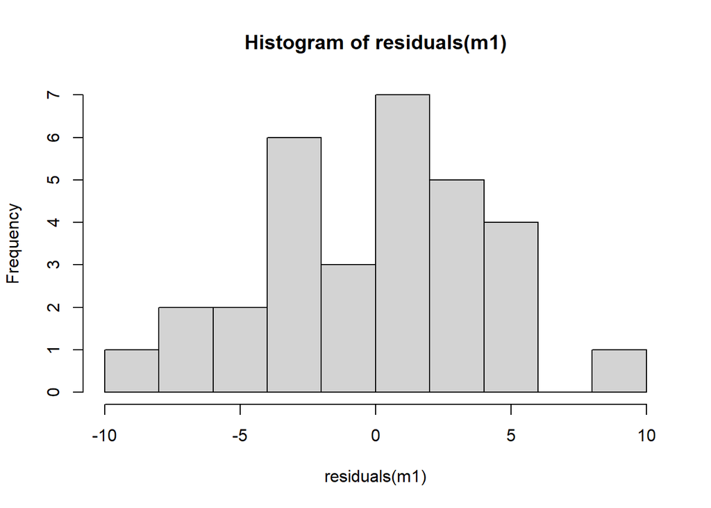

```r
hist(residuals(m1),breaks=10,col="light grey")
```

Diagnostic plots for the model can reveal whether or not modelling assumptions are reasonable. In this case, there is visual evidence to suggest that the assumptions are not satisfied - note in particular the trend observed in the plot of residuals vs fitted values:

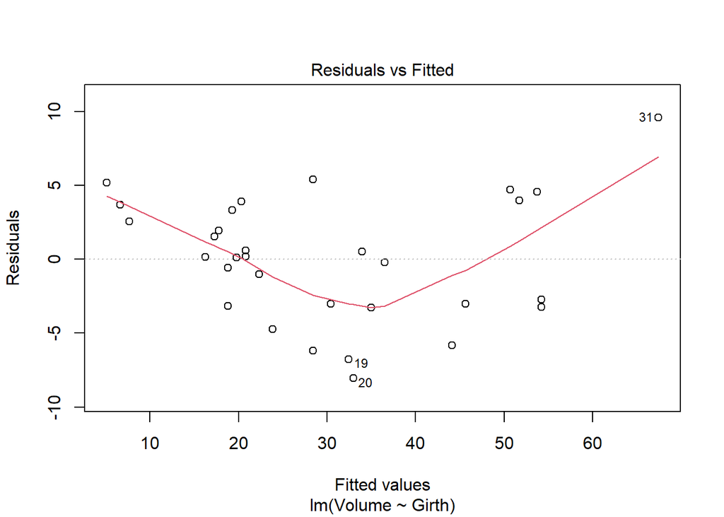

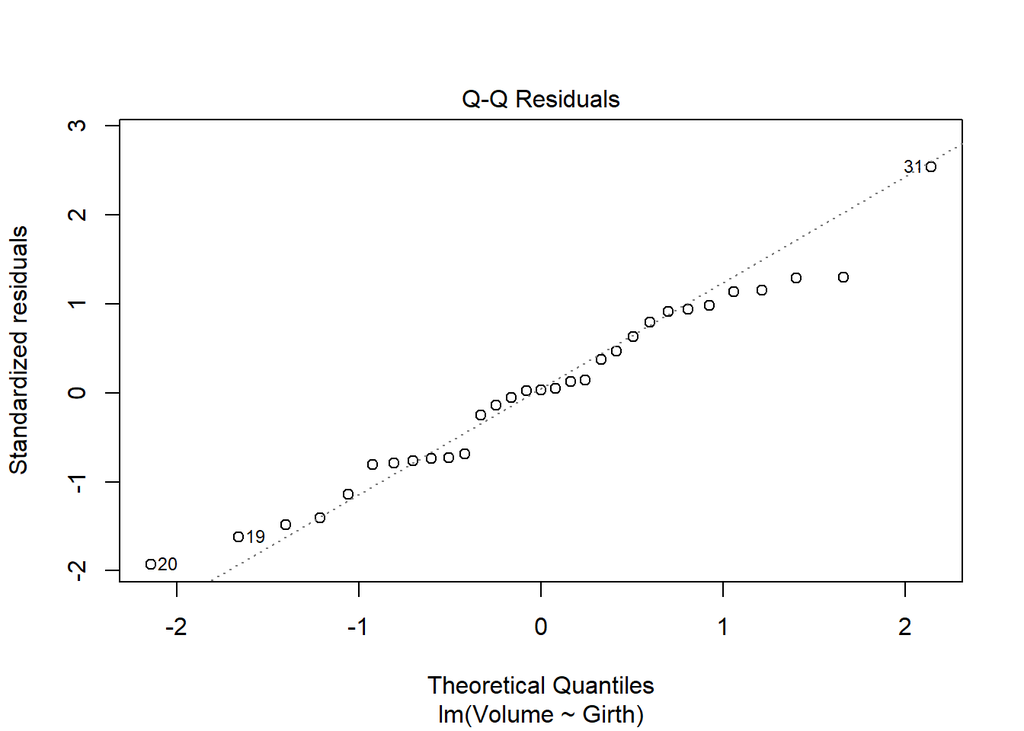

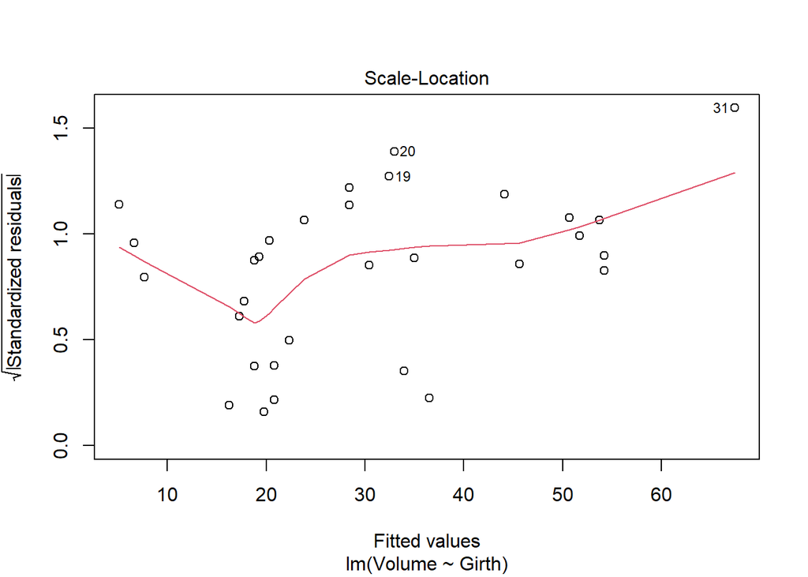

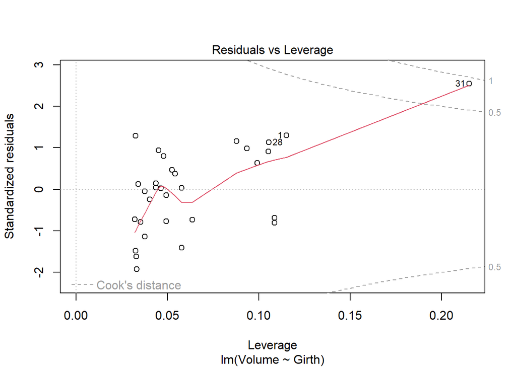

```r
plot(m1)
```

# **Assessing the quality of linear models**

Let’s see what happens if we try to describe a non-linear relationship using a linear model. Consider the sine function in the range [0,1.5*pi):

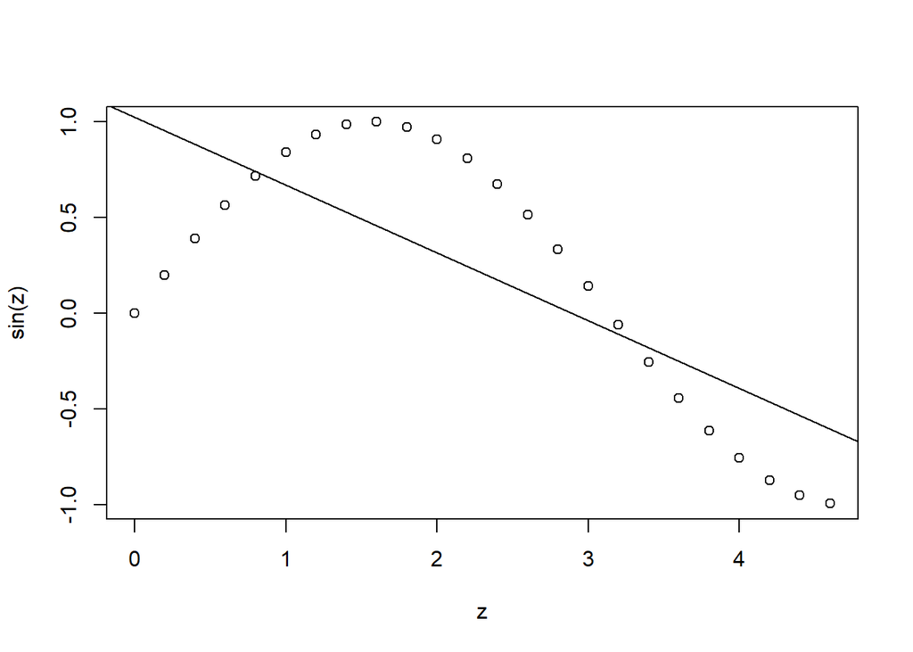

```r
z = seq(0,1.5*pi,0.2)
plot(sin(z)~z)
m0 = lm(sin(z)~z)
abline(m0)
```

In this case, it is clear that a linear model is not appropriate for describing the relationship. However, we are able to fit a linear model, and the linear model summary does not identify any major concerns:

```r
summary(m0)
```

```
##
## Call:
## lm(formula = sin(z) ~ z)
##
## Residuals:
##      Min       1Q   Median       3Q      Max
## -1.02542 -0.37054  0.01294  0.42276  0.59274
##
## Coefficients:
##             Estimate Std. Error t value Pr(>|t|)
## (Intercept)  1.02542    0.18641   5.501 1.58e-05 ***
## z           -0.35443    0.06944  -5.104 4.09e-05 ***
## ---
## Signif. codes:  0 '***' 0.001 '**' 0.01 '*' 0.05 '.' 0.1 ' ' 1
##
## Residual standard error: 0.471 on 22 degrees of freedom
## Multiple R-squared:  0.5422, Adjusted R-squared:  0.5214
## F-statistic: 26.05 on 1 and 22 DF,  p-value: 4.094e-05
```

Here we see that the overall p-value is low enough to suggest that the model has significant utility, and both terms (the intercept and the coefficient of `z`) are significantly different from zero. The R^2 value of 0.5422 is high enough to indicate that there is a reasonably strong correlation between `sin(z)` and `z` in this range.

This information is misleading, as we know that a linear model is inappropriate in this case. Indeed, the linear model summary does not check whether the underlying model assumptions are satisfied.

By observing strong patterns in the diagnostic plots, we can see that the modelling assumptions are not satisified in this case.

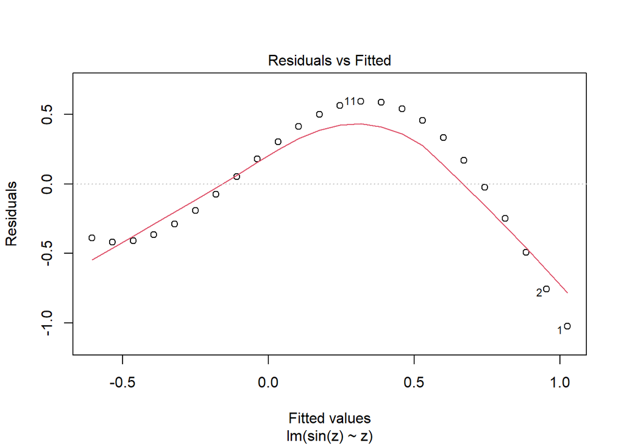

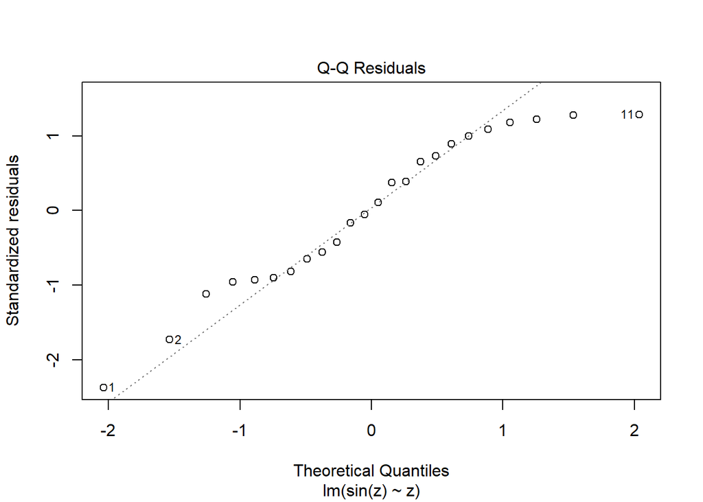

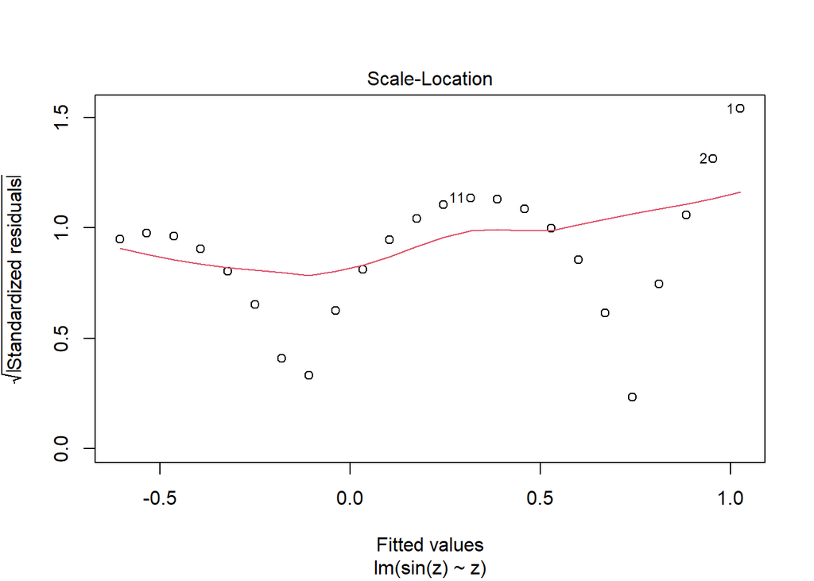

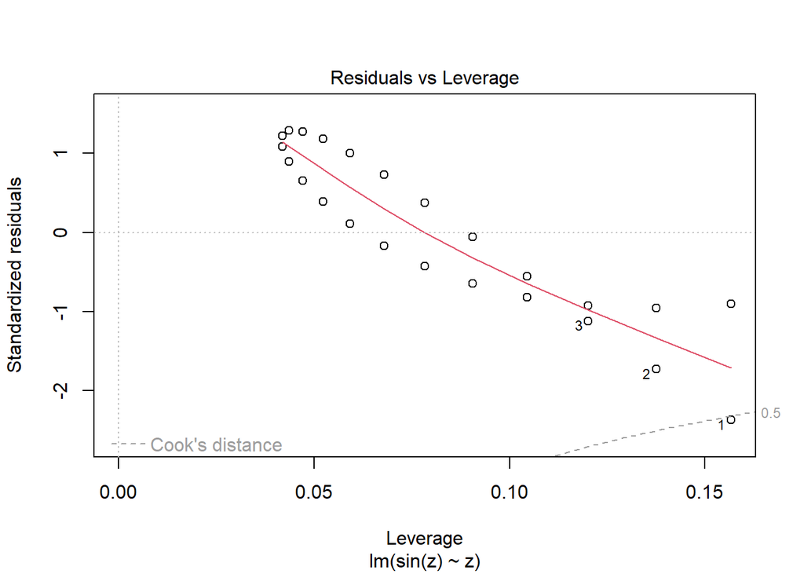

```r
plot(m0)
```

# Section 6: **Modelling Non-Linear Relationships**

It is sometimes possible to use linear models to describe non-linear relationships (which is perhaps counterintuitive!). This can be achieved by applying transformations to the variable(s) in order to linearise the relationship, whilst ensuring that modelling assumptions are satisfied.

Another in-built dataset `cars` provides the speeds and associated stopping distances of cars in the 1920s.

Let’s construct a linear model to predict stopping distance using speed:

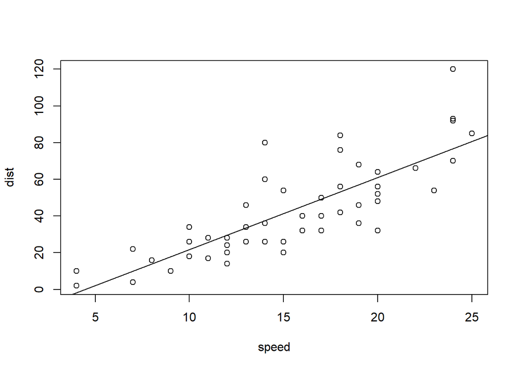

```r
plot(dist~speed,data=cars)
m2 = lm(dist~speed,data=cars)
abline(m2)
```

```r
summary(m2)
```

```
##
## Call:
## lm(formula = dist ~ speed, data = cars)
##
## Residuals:
##     Min      1Q  Median      3Q     Max
## -29.069  -9.525  -2.272   9.215  43.201
##
## Coefficients:
##             Estimate Std. Error t value Pr(>|t|)
## (Intercept) -17.5791     6.7584  -2.601   0.0123 *
## speed         3.9324     0.4155   9.464 1.49e-12 ***
## ---
## Signif. codes:  0 '***' 0.001 '**' 0.01 '*' 0.05 '.' 0.1 ' ' 1
##
## Residual standard error: 15.38 on 48 degrees of freedom
## Multiple R-squared:  0.6511, Adjusted R-squared:  0.6438
## F-statistic: 89.57 on 1 and 48 DF,  p-value: 1.49e-12
```

In addition, the plot of residuals versus fitted values indicates potential issues with variance stability:

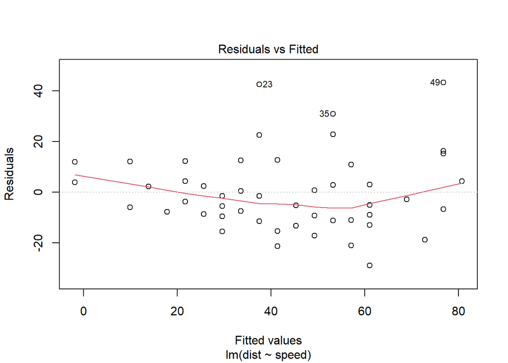

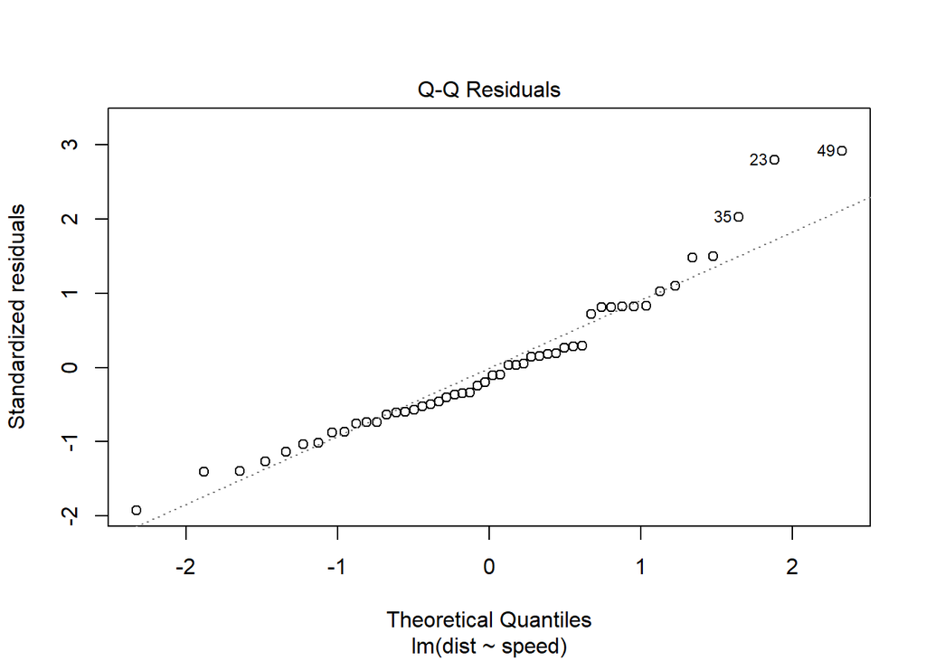

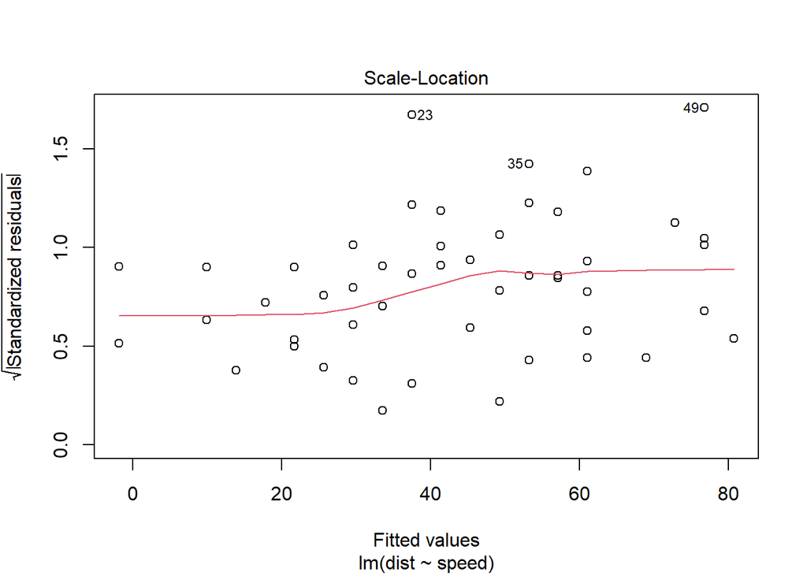

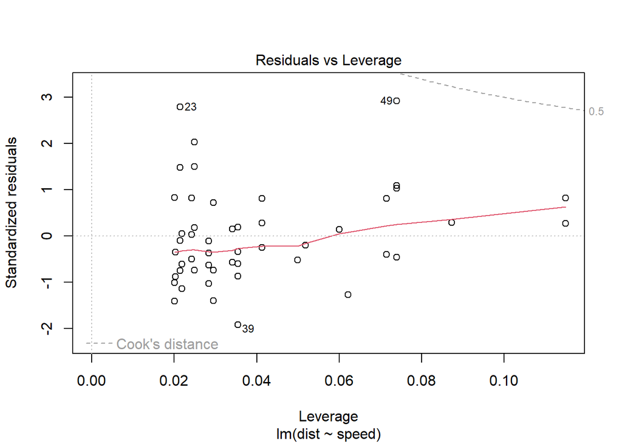

```r
plot(m2)
```

In this case, variance stability can be aided by a square-root transformation of the response variable:

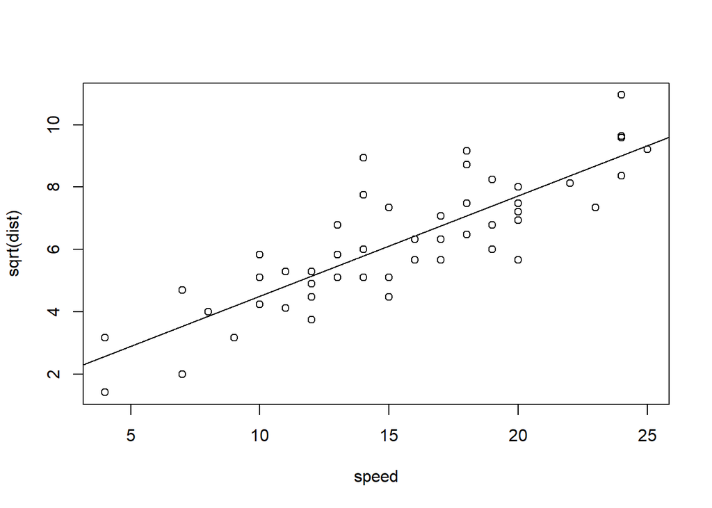

```r
plot(sqrt(dist)~speed,data=cars)
m3 = lm(sqrt(dist)~speed,data=cars)
abline(m3)
```

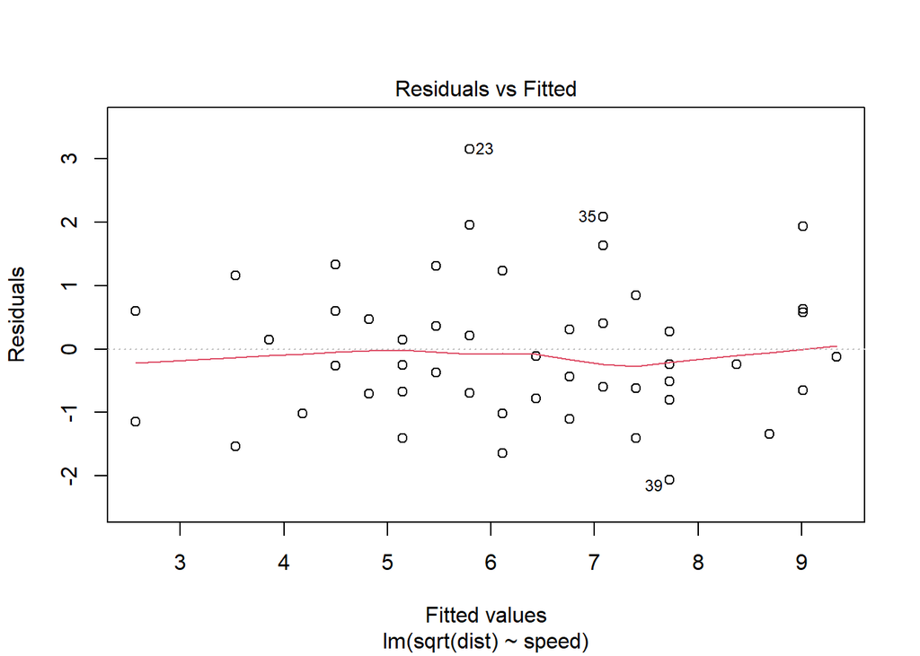

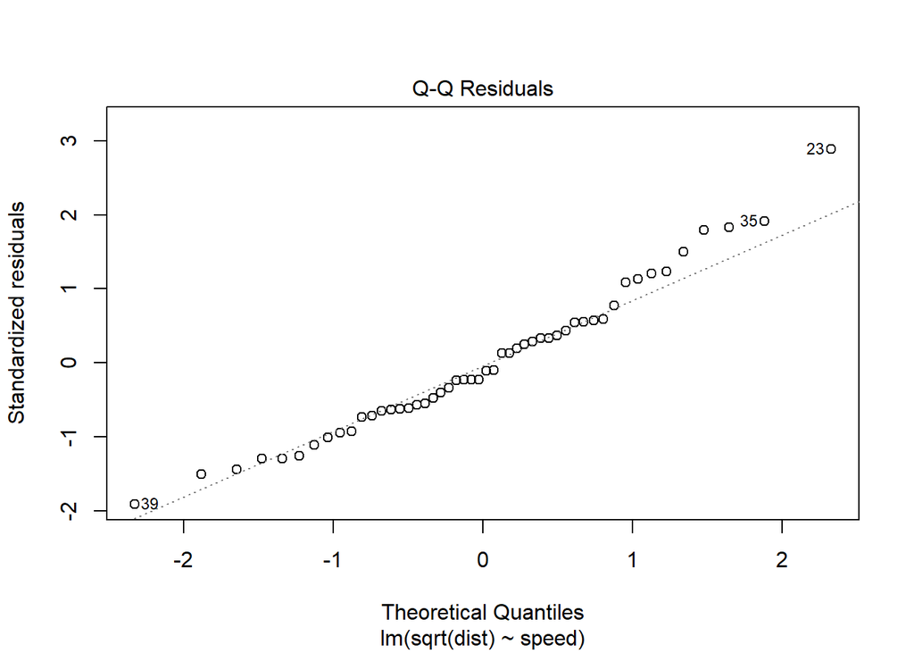

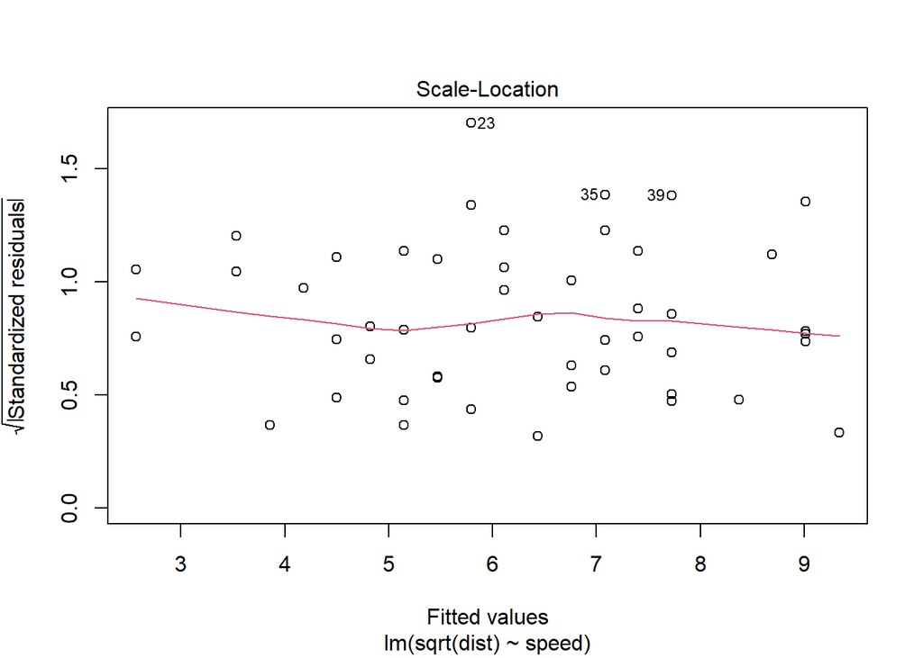

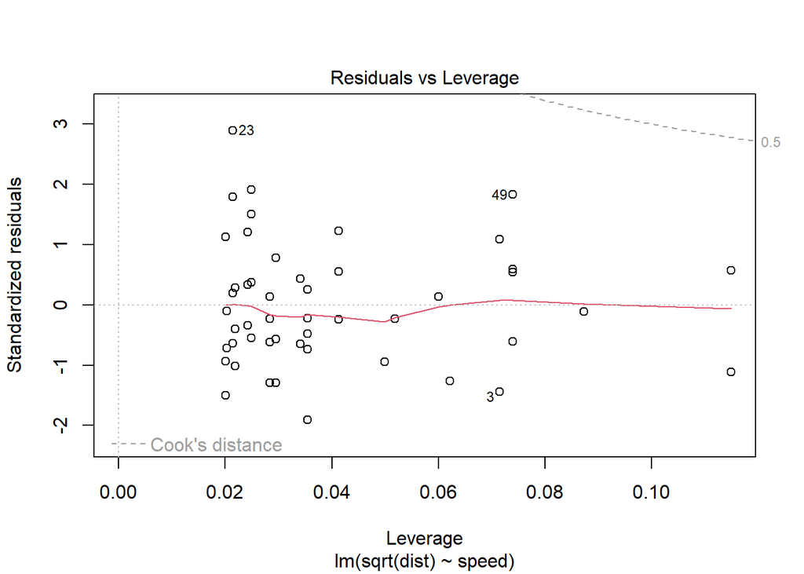

```r
plot(m3)
```

```r
summary(m3)
```

```
##
## Call:
## lm(formula = sqrt(dist) ~ speed, data = cars)
##
## Residuals:
##     Min      1Q  Median      3Q     Max
## -2.0684 -0.6983 -0.1799  0.5909  3.1534
##
## Coefficients:
##             Estimate Std. Error t value Pr(>|t|)
## (Intercept)  1.27705    0.48444   2.636   0.0113 *
## speed        0.32241    0.02978  10.825 1.77e-14 ***
## ---
## Signif. codes:  0 '***' 0.001 '**' 0.01 '*' 0.05 '.' 0.1 ' ' 1
##
## Residual standard error: 1.102 on 48 degrees of freedom
## Multiple R-squared:  0.7094, Adjusted R-squared:  0.7034
## F-statistic: 117.2 on 1 and 48 DF,  p-value: 1.773e-14
```

We’ll now try a log-log transformation, that is applying a log transformation to the predictor and response variables. This represents a power relationship between the two variables.

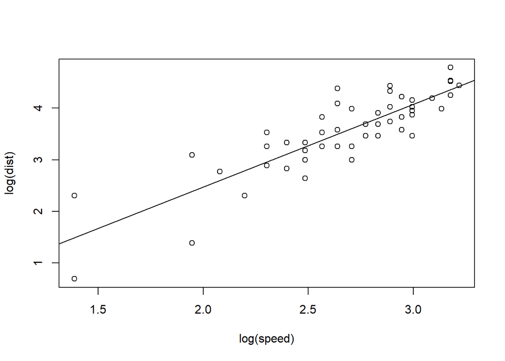

```r
plot(log(dist)~log(speed),data=cars)
m4 = lm(log(dist)~log(speed),data=cars)
abline(m4)
```

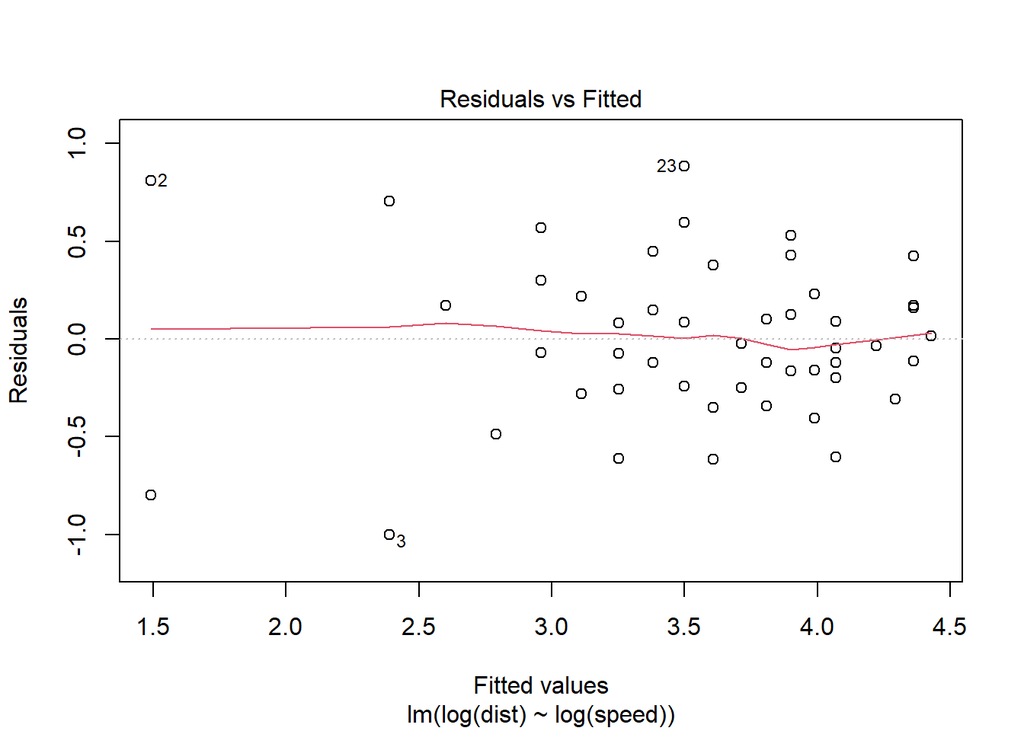

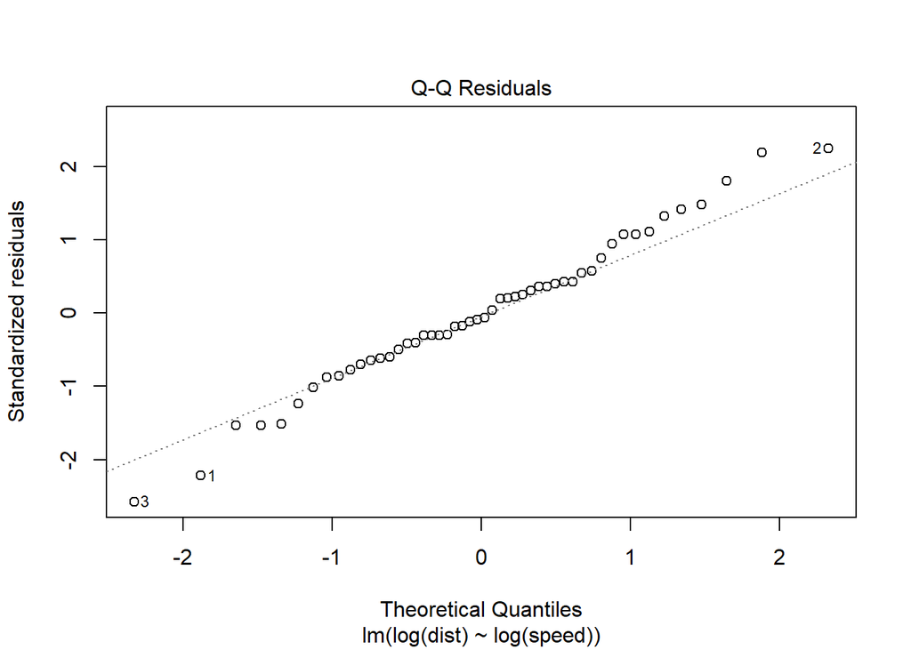

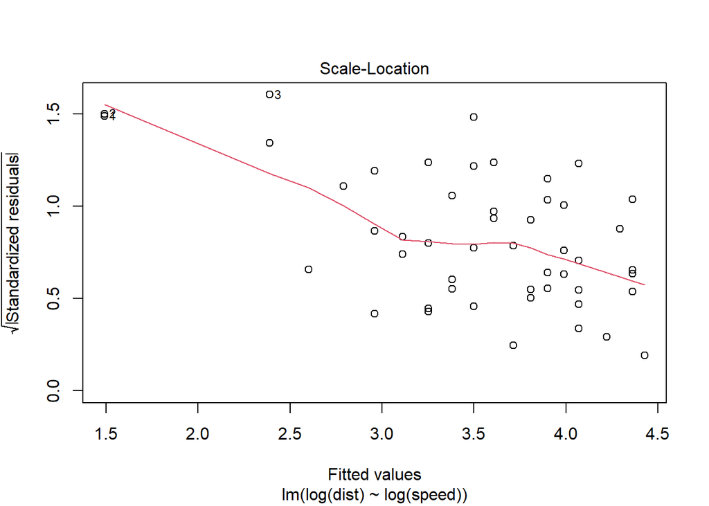

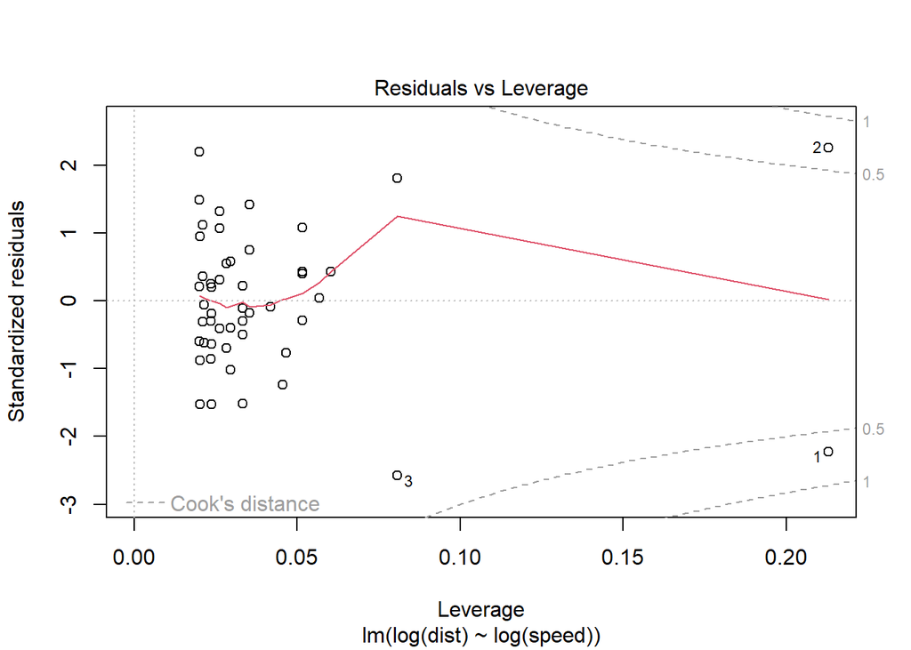

```r
plot(m4)
```

```r
summary(m4)
```

```
##
## Call:
## lm(formula = log(dist) ~ log(speed), data = cars)
##
## Residuals:
##      Min       1Q   Median       3Q      Max
## -1.00215 -0.24578 -0.02898  0.20717  0.88289
##
## Coefficients:
##             Estimate Std. Error t value Pr(>|t|)
## (Intercept)  -0.7297     0.3758  -1.941   0.0581 .
## log(speed)    1.6024     0.1395  11.484 2.26e-15 ***
## ---
## Signif. codes:  0 '***' 0.001 '**' 0.01 '*' 0.05 '.' 0.1 ' ' 1
##
## Residual standard error: 0.4053 on 48 degrees of freedom
## Multiple R-squared:  0.7331, Adjusted R-squared:  0.7276
## F-statistic: 131.9 on 1 and 48 DF,  p-value: 2.259e-15
```

The R^2 value is improved, and the diagnostic plots don’t look too unreasonable. However, again the intercept term does not have significant utility. So we’ll now remove it from the model:

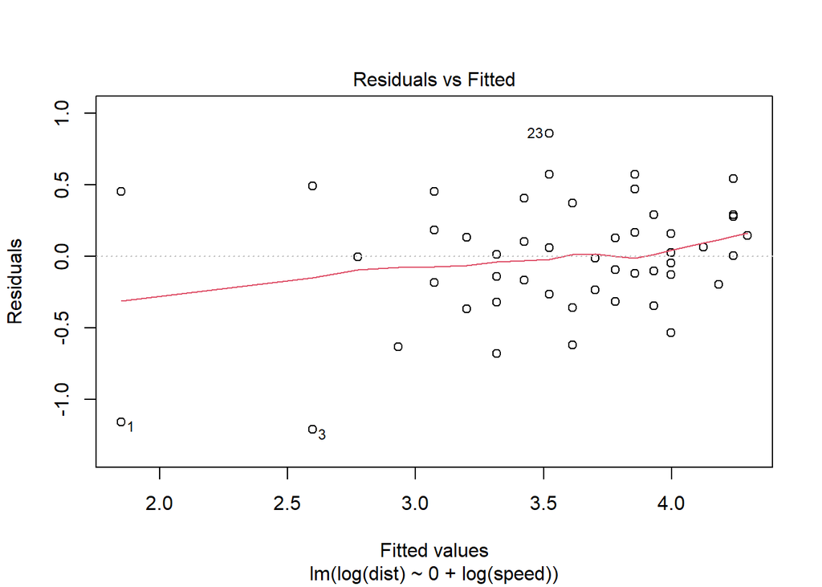

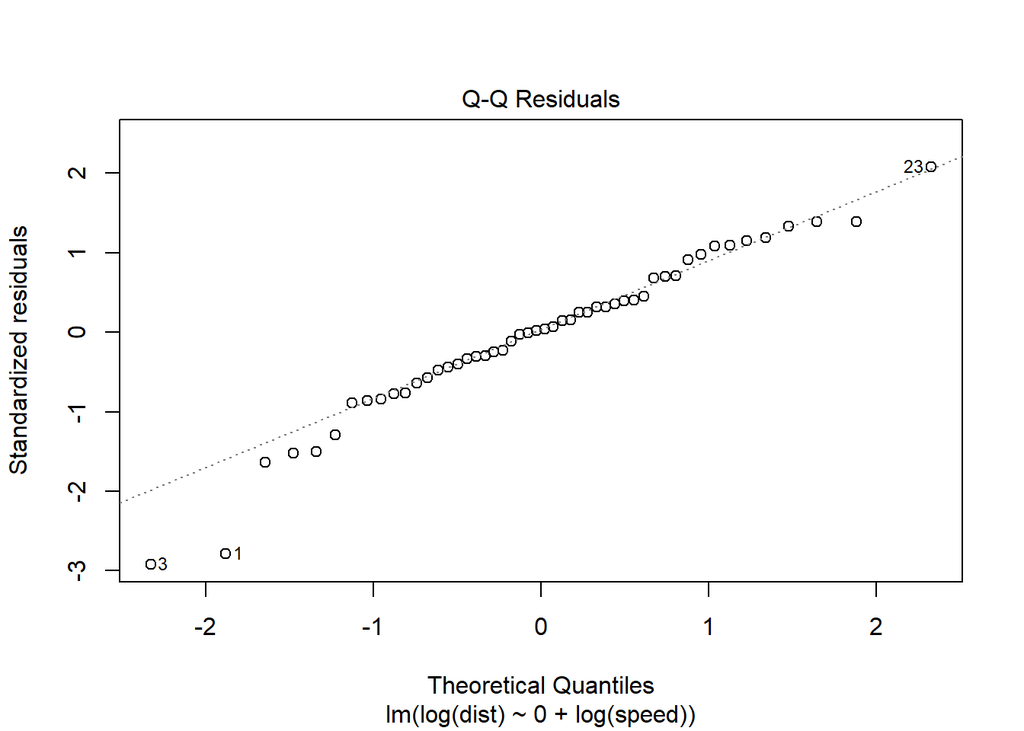

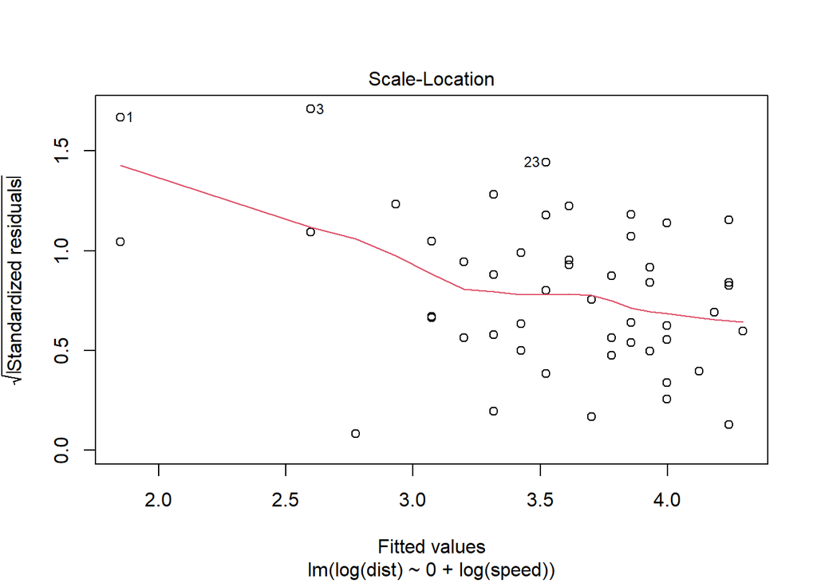

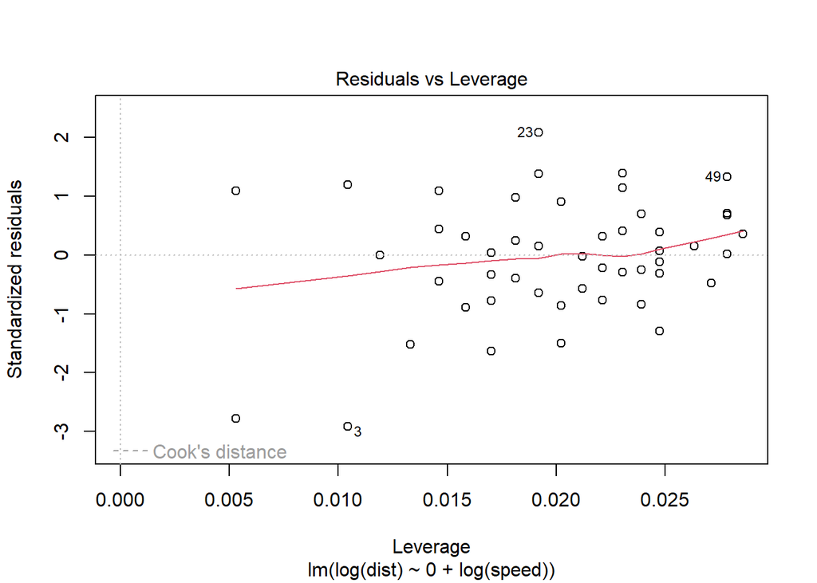

```r
m5 = lm(log(dist)~0+log(speed),data=cars)
plot(m5)
```

```r
summary(m5)
```

```
##
## Call:
## lm(formula = log(dist) ~ 0 + log(speed), data = cars)
##
## Residuals:
##      Min       1Q   Median       3Q      Max
## -1.21083 -0.22501  0.01129  0.25636  0.85978
##
## Coefficients:
##            Estimate Std. Error t value Pr(>|t|)
## log(speed)  1.33466    0.02187   61.02   <2e-16 ***
## ---
## Signif. codes:  0 '***' 0.001 '**' 0.01 '*' 0.05 '.' 0.1 ' ' 1
##
## Residual standard error: 0.4166 on 49 degrees of freedom
## Multiple R-squared:  0.987,  Adjusted R-squared:  0.9867
## F-statistic:  3724 on 1 and 49 DF,  p-value: < 2.2e-16
```

This model seems reasonable. However, remember that R^2 values corresponding to models without an intercept aren’t meaningful (or at least can’t be compared against models with an intercept term).

We can now transform the model back, and display the regression curve on the plot:

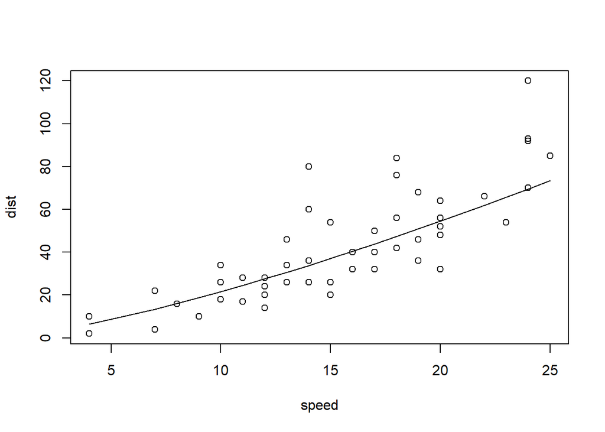

```r
plot(dist~speed,data=cars)
x = order(cars$speed)
lines(exp(fitted(m5))[x]~cars$speed[x])
```

# **Relationship between the t-test, ANOVA and linear regression**

In the ANOVA session we looked at the `diet` dataset, and performed the t-test and ANOVA. Here’s a recap:

```r
# import
diet = read.csv("./CourseData/diet.csv",row.names=1)
diet$weight.loss = diet$initial.weight - diet$final.weight
diet$diet.type   = factor(diet$diet.type,levels=c("A","B","C"))
diet$gender      = factor(diet$gender,levels=c("Female","Male"))
# comparison
t.test(weight.loss~diet.type,data=diet[diet$diet.type!="B",],var.equal = TRUE)
```

```
##
##  Two Sample t-test
##
## data:  weight.loss by diet.type
## t = -2.8348, df = 49, p-value = 0.006644
## alternative hypothesis: true difference in means between group A and group C is not equal to 0
## 95 percent confidence interval:
##  -3.1582988 -0.5379975
## sample estimates:
## mean in group A mean in group C
##        3.300000        5.148148
```

```r
summary(aov(weight.loss~diet.type,data=diet[diet$diet.type!="B",]))
```

```
##             Df Sum Sq Mean Sq F value  Pr(>F)
## diet.type    1   43.4    43.4   8.036 0.00664 **
## Residuals   49  264.6     5.4
## ---
## Signif. codes:  0 '***' 0.001 '**' 0.01 '*' 0.05 '.' 0.1 ' ' 1
```

Note that the p-values for both the t-test and ANOVA are the same. This is because these tests are equivalent (in the 2-sample case). They both test the same hypothesis.

Also, the F-test statistic is equal to the square of the t-test statistic (-2.8348^2 = 8.036). Again, this is only true for the 2-sample case.

Now let’s use a different strategy. Instead of directly testing whether there is a difference between the two groups, let’s attempt to create a linear model describing the relationship between `weight.loss` and `diet.type`. Indeed, it is possible to construct a linear model where the independent variable(s) are categorical - they do not have to be continuous or even ordinal!

```r
summary(lm(weight.loss~diet.type,data=diet[diet$diet.type!="B",]))
```

```
##
## Call:
## lm(formula = weight.loss ~ diet.type, data = diet[diet$diet.type !=
##     "B", ])
##
## Residuals:
##     Min      1Q  Median      3Q     Max
## -4.6481 -1.5241  0.1519  1.6519  5.7000
##
## Coefficients:
##             Estimate Std. Error t value Pr(>|t|)
## (Intercept)   3.3000     0.4744   6.957 7.74e-09 ***
## diet.typeC    1.8481     0.6520   2.835  0.00664 **
## ---
## Signif. codes:  0 '***' 0.001 '**' 0.01 '*' 0.05 '.' 0.1 ' ' 1
##
## Residual standard error: 2.324 on 49 degrees of freedom
## Multiple R-squared:  0.1409, Adjusted R-squared:  0.1234
## F-statistic: 8.036 on 1 and 49 DF,  p-value: 0.006644
```

You can see that the p-value corresponding to the `diet.type` term is the same as the overall p-value of the linear model, which is also the same as the p-value from the t-test and ANOVA. Note also that the F-test statistic is the same as given by the ANOVA.

So, we are also able to use the linear model to test the hypothesis that there is a difference between the two diet groups, as well as provide a more detailed description of the relationship between `weight.loss` and `diet.type`.

# **Practical Exercises**

## Old Faithful

The inbuilt R dataset `faithful` pertains to the waiting time between eruptions and the duration of the eruption for the Old Faithful geyser in Yellowstone National Park, Wyoming, USA.

- Create a simple linear regression model that models the eruption duration `faithful$eruptions` using waiting time `faithful$waiting` as the independent variable, storing the model in a variable. Look at the summary of the model.
  - What are the values of the estimates of the intercept and coefficient of ‘waiting’?
  - What is the R^2 value?
  - Does the model have significant utility?
  - Are neither, one, or both of the parameters significantly different from zero?
  - Can you conclude that there is a linear relationship between the two variables?
- Plot the eruption duration against waiting time. Is there anything noticeable about the data?
- Draw the regression line corresponding to your model onto the plot. Based on this graphical representation, does the model seem reasonable?
- Generate the four diagnostic plots corresponding to your model. Contemplate the appropriateness of the model for describing the relationship between eruption duration and waiting time.

## Anscombe datasets

Consider the inbuilt R dataset `anscombe`. This dataset contains four x-y datasets, contained in the columns: (x1,y1), (x2,y2), (x3,y3) and (x4,y4).

- For each of the four datasets, calculate and test the correlation between the x and y variables. What do you conclude?
- For each of the four datasets, create a linear model that regresses y on x. Look at the summaries corresponding to these models. What do you conclude?
- For each of the four datasets, create a plot of y against x. What do you conclude?

## Pharmacokinetics of Indomethacin

Consider the inbuilt R dataset `Indometh`, which contains data on the pharmacokinetics of indometacin.

- Plot `Indometh$time` versus `Indometh$conc` (concentration). What is the nature of the relationship between `time` and `conc`?
- Apply monotonic transformations to the data so that a simple linear regression model can be used to model the relationship (ensure both linearity and stabilised variance, within reason). Create a plot of the transformed data, to confirm that the relationship seems linear.
- After creating the linear model, inspect the diagnostic plots to ensure that the assumptions are not violated (too much). Are there any outliers with large influence? What are the parameter estimates? Are both terms significant?
- Add a line to the plot showing the linear relationship between the transformed data.
- Now regenerate the original plot of `time` versus `conc` (i.e. the untransformed data). Using the `lines` function, add a curve to the plot corresponding to the fitted values of the model.